# Data Science Notes: Section 1 through 15

### Data Science (15 sections) Compiled by :

```
               Alem H Fitwi,
               PhD Student (Privacy, Deep Learning, Networking (Edge Computing), IoD, Surveillance Systems),
               GA-Data Analyst,
               Binghamton University-State University of New York
               December, 2017
```

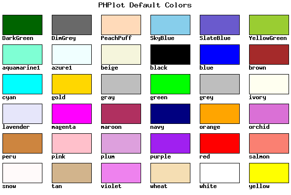

```python
from IPython.display import Image
from IPython.core.display import HTML
Image('./0_pictures/colors.png')
# <img src='./0_pictures/colors.png'/>
```

## Prerequisites Python 3.x

# Section 1: Introduction Data Science

### 1.1: Data Science

==> What data science is

==> Data Science Pipeline

Data science is the analysis of raw data to produce actionable results

Data Science will lead to data driven dicisions, rathern than gut feelings

Data --> Decisions --> Actions

Today data is produced at unprecedented pace

90% of data created within the past two years as of 2018 (IBM)

There are three skills related to data science

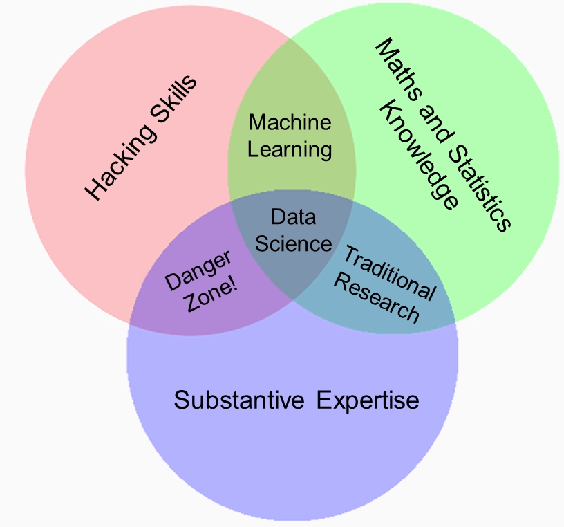

```python
from IPython.display import Image
from IPython.core.display import HTML
Image('ds_1.png')
```

Data Science pipeline

```
The steps of data science pipeline
```

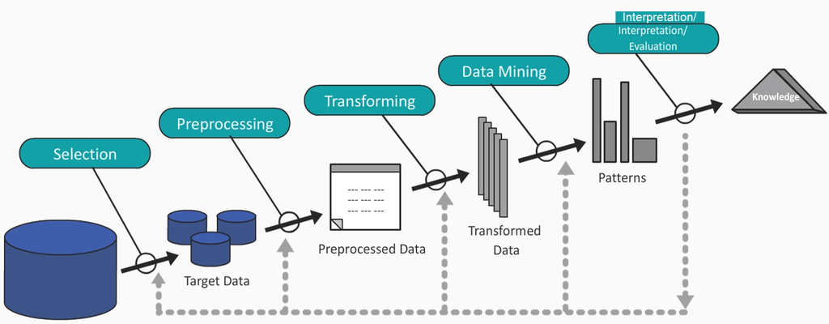

```python
from IPython.display import Image
from IPython.core.display import HTML
print("The steps of data science pipeline")
Image('ds_2.png')
```

### Why Python?

One of the most widely used programs in data science alogside R

Python tends to be faster than R

Python is free, and very well supported by the community

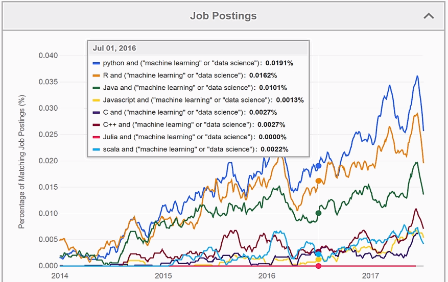

```python
from IPython.display import Image
from IPython.core.display import HTML
Image('ds_3.png')
```

Most Important Python Packages

numpy: import numpy as np  
scipy: import scipy  
pandas: import pandas as pd  
sklearn: import sklearn  
matplotlib: import matplotlib.pyplot as plt  
seaborn: import seaborn as sn

### 1.2: Python Data Science Ecosystem

### Jupyter Notebooks

Interactive Coding

Both text [markdown] and python code on the same page

It can output repots in pdf, html, ...

It works with other languages as well

We will use jupyter for our live coding and visualization

### Numpy

Fundamental package for scientific computing

Arrays

Linear algebra, Fourier transforms, random number capabilities

### Pandas

Data structures and data analysis tools for the Python programming language

Dataframes

Reading/Writing data

Grouping

Simmarizing

Data manipulation

### Data VIsualization: Matplotlib, Seaborn

Histograms

Bar Charts

Boxplots

Scatter plots

Line graphs

### Scikit-learn

Simple and efficient tools for data mining and data analysis  
Accessible to everybody, and reusable in various contexts  
Built on NumPy, SciPy, and matplotlib  
Open source, commercially usable - BSD license

components of the the sckit-learn (sklearn) package  
Classification: Identifying to which category an object belongs to.  
Regression: Predicting a continuous-valued attribute associated with an object.  
CLustering: Automatic grouping of similar objects into sets  
Dimensionality Reduction: Reducing the number of random variables to consider.  
Model Selection: Comparing, validating and choosing parameters and models.  
Preprocessing: Feature extraction and normalization.

[output not shown]

[figure not shown]

```python
from IPython.display import Image
from IPython.core.display import HTML
print("The steps of data science pipeline")
Image('ds_29.png')
```

### Summary

Data science is one of th hottest areas due to increase in data and computing

Data science is the process of analyzing raw data to produce actiionable results

We will learn how to conduct data science by using python

The most important and widely used libraries in conducting data science with python including Jupyter, Numpy, Pnadas, Matplotlib, Seaborn, and Scikit-learn

# Section 2: Inatalling Anaconda

Install Anaconda (Jupyter, Markdown, spyder)

Download anaconda from www.anaconda.com/download

Start Jupyter:

```
start menu --> anaconda --> anaconda navigator--> jupyter launch

cmd prompt: jupyter notebook
```

Basics of Jupyter: Markdown for texts Section 1: for coloring New python environment

```
# Header 1, ## header 2, ### header 3
```

# Section 3: Numpy

Creating, indexing, and manipulating 1D arrays

Creating, indexing, and manipulating 2D arrays

Functions, methods, and attributes in Numpy

Probability and statistics with Numpy

### Numpy Package

Numpy is the fundamental package for scientific computing with Python

Numpy Arrays:

```
Unlike lists allow for mathematical operations over array
Allow for vectorization
Based on C, thus faster than python lists
Arrays are of single type (For example, numeric, string, boolean)
```

## 2.1 1D Array

How to create 1D array

How to index or subset an array

Slicing an array

Perform logical indexing on arrays

## Creating an array

```python
import  numpy as np
```

```python
# create a list
x=[150,200,300,450]
```

```python
# convert the list to numpy array
y=np.array(x)
```

```python
y
```

```
array([150, 200, 300, 450])
```

```python
# check type
type(y)
```

```
numpy.ndarray
```

```python
# summing list = cpncatenating
x+x
```

```
[150, 200, 300, 450, 150, 200, 300, 450]
```

```python
# Multiplication
x*3
```

```
[150, 200, 300, 450, 150, 200, 300, 450, 150, 200, 300, 450]
```

```python
# Multiply numpy --> different from list
y*3  # multiplying an array in one go
```

```
array([ 450,  600,  900, 1350])
```

```python
y
```

```
array([150, 200, 300, 450])
```

### Indexing

0 to length of array -1 --> [0, n-1]

```python
y[0]
```

```
150
```

```python
y[3]
```

```
450
```

```python
y[-1] # last element
```

```
450
```

### Subnetting and Slicing

```python
y[0:3]
```

```
array([150, 200, 300])
```

```python
y[:3]
```

```
array([150, 200, 300])
```

```python
y[2:]
```

```
array([300, 450])
```

```python
y[-3:-1]  # last index is not included
```

```
array([200, 300])
```

### Logical Indexing

It can be used for subsetting

```python
y
```

```
array([150, 200, 300, 450])
```

```python
y>200
```

```
array([False, False,  True,  True])
```

```python
y==300
```

```
array([False, False,  True, False])
```

```python
y!=200
```

```
array([ True, False,  True,  True])
```

### Conditional Assignments

```python
# Subsetting using logical indexing
y[y!=200]
```

```
array([150, 300, 450])
```

```python
y[y>=200]
```

```
array([200, 300, 450])
```

```python
y[y==150]
```

```
array([150])
```

## 2.2 2D Arrays with Numpy

### Creating 2D Arrays

How to create 2D arrays

How to index or subset on 2D arrays

Slicing a 2D array

Perform logical indexing on 2D arrays

```python
x = [list(range(0,6)),list(range(9,15)),list(range(20,25))] #List of lists
x
```

```
[[0, 1, 2, 3, 4, 5], [9, 10, 11, 12, 13, 14], [20, 21, 22, 23, 24]]
```

```python
len(x)
```

```
3
```

```python
y=np.array(x)
y
```

```
array([list([0, 1, 2, 3, 4, 5]), list([9, 10, 11, 12, 13, 14]),
       list([20, 21, 22, 23, 24])], dtype=object)
```

```python
yy = np.hstack(x) #1D array
yy
```

```
array([ 0,  1,  2,  3,  4,  5,  9, 10, 11, 12, 13, 14, 20, 21, 22, 23, 24])
```

```python
V=np.array([[1, 0, 0],[0,1, 0],[0,0,1]])
V
```

```
array([[1, 0, 0],
       [0, 1, 0],
       [0, 0, 1]])
```

### Indexing

```python
V[0]
```

```
array([1, 0, 0])
```

```python
V[0][0]
```

```
1
```

```python
V[0][-1]
```

```
0
```

```python
V[2][-1]
```

```
1
```

```python
V[0,1]
```

```
0
```

```python
V[2,-1]
```

```
1
```

```python
x[0,1]  #not applicable for a list
```

```
---------------------------------------------------------------------------
TypeError                                 Traceback (most recent call last)
<ipython-input-163-29b97d4957dc> in <module>
----> 1 x[0,1]  #not applicable for a list

TypeError: list indices must be integers or slices, not tuple
```

### Slicing and Subsnetting

```python
x[0:1]
```

[output not shown]

```python
V[0:2,1:4]
```

[output not shown]

### Logical Indexing

```python
V
```

```
array([[1, 0, 0],
       [0, 1, 0],
       [0, 0, 1]])
```

```python
V[1,3:5]
```

```
array([], dtype=int32)
```

```python
V[V>0]
```

```
array([1, 1, 1])
```

```python
V[:,2]>0
```

```
array([False, False,  True])
```

```python
V[:,2][V[:,2]>0]
```

```
array([1])
```

```python
# All rows from a column
```

```python
V[:,2] #columns, rows
```

```
array([0, 0, 1])
```

```python
# All columns from a row
```

```python
V[2, :]
```

```
array([0, 0, 1])
```

## 2.3 Functions and Methods in Numpy

### Create an Array

```python
np.arange(5)
```

```
array([0, 1, 2, 3, 4])
```

```python
np.arange(4,5)
```

```
array([4])
```

```python
np.arange(4,16,4)
```

```
array([ 4,  8, 12])
```

```python
np.linspace(0,1,10)
```

```
array([0.        , 0.11111111, 0.22222222, 0.33333333, 0.44444444,
       0.55555556, 0.66666667, 0.77777778, 0.88888889, 1.        ])
```

```python
np.logspace(0,5,10)
```

```
array([1.00000000e+00, 3.59381366e+00, 1.29154967e+01, 4.64158883e+01,
       1.66810054e+02, 5.99484250e+02, 2.15443469e+03, 7.74263683e+03,
       2.78255940e+04, 1.00000000e+05])
```

### Reshaping an array

```python
x=np.arange(12)
```

```python
x
```

```
array([ 0,  1,  2,  3,  4,  5,  6,  7,  8,  9, 10, 11])
```

```python
x.reshape(4,3) # length should be divisible by 3 and 4
```

```
array([[ 0,  1,  2],
       [ 3,  4,  5],
       [ 6,  7,  8],
       [ 9, 10, 11]])
```

### Get the size and shape

```python
# Size and shape are attributes and not followed by paranthesis
```

```python
x
```

```
array([ 0,  1,  2,  3,  4,  5,  6,  7,  8,  9, 10, 11])
```

```python
x.size
```

```
12
```

```python
x.shape
```

```
(12,)
```

```python
x.reshape(3,4)
```

```
array([[ 0,  1,  2,  3],
       [ 4,  5,  6,  7],
       [ 8,  9, 10, 11]])
```

### Check Truth Value of an array

```python
x
```

```
array([ 0,  1,  2,  3,  4,  5,  6,  7,  8,  9, 10, 11])
```

```python
x.any() # True if at least one nonzero e/t exists
```

```
True
```

```python
x.all() # no zero value
```

```
False
```

### Transpose

```python
x.reshape(4,3).T
```

```
array([[ 0,  3,  6,  9],
       [ 1,  4,  7, 10],
       [ 2,  5,  8, 11]])
```

### Maths

```python
y=x.reshape(4,3)
y
```

```
array([[ 0,  1,  2],
       [ 3,  4,  5],
       [ 6,  7,  8],
       [ 9, 10, 11]])
```

```python
y+5 # broadcast to every e/t
```

```
array([[ 5,  6,  7],
       [ 8,  9, 10],
       [11, 12, 13],
       [14, 15, 16]])
```

```python
z=np.arange(4).reshape(4,1)
z
```

```
array([[0],
       [1],
       [2],
       [3]])
```

```python
y+z # broadcast the column
```

```
array([[ 0,  1,  2],
       [ 4,  5,  6],
       [ 8,  9, 10],
       [12, 13, 14]])
```

```python
x.mean()
```

```
5.5
```

```python
x.sum()
```

```
66
```

```python
x.max()
```

```
11
```

```python
x.min()
```

```
0
```

```python
x.std()
```

```
3.452052529534663
```

```python
x.prod()
```

```
0
```

```python
x[1:].prod()
```

```
39916800
```

## 2.4 Random Numbers and Distributions

### Seeding

```python
import numpy as np
import matplotlib.pyplot as plt
%matplotlib inline
```

```python
np.random.seed(123)
```

```python
np.random.rand(5)
```

```
array([0.69646919, 0.28613933, 0.22685145, 0.55131477, 0.71946897])
```

```python
np.random.rand(5,3)
```

```
array([[0.42310646, 0.9807642 , 0.68482974],
       [0.4809319 , 0.39211752, 0.34317802],
       [0.72904971, 0.43857224, 0.0596779 ],
       [0.39804426, 0.73799541, 0.18249173],
       [0.17545176, 0.53155137, 0.53182759]])
```

```python
# Between a and b
a=6; b=12;
```

```python
(b-a)*np.random.rand(5)+a
```

```
array([ 9.80640575, 11.09659076, 10.34673195,  9.66614106, 10.3346603 ])
```

### Normal Distribution

```python
np.random.randn(5)
```

```
array([-1.10098526, -1.4103012 , -0.74765132, -0.98486761, -0.74856868])
```

```python
np.random.randn(5,4)
```

```
array([[ 0.24036728, -1.85563747, -1.7794548 , -2.75022426],
       [-0.23415755, -0.69598118, -1.77413406,  2.36160126],
       [ 0.03499308, -0.34464169, -0.72503229,  1.03960617],
       [-0.24172804, -0.11290536, -1.66069578,  0.01353855],
       [ 0.33737412, -0.92662298,  0.27574741,  0.37085233]])
```

```python
mu=5; sigma=2
```

```python
mu+sigma*np.random.randn(5)
```

```
array([7.34861429, 0.93541504, 6.16501658, 3.5576484 , 1.5951528 ])
```

```python
x1=np.random.randn(10000)
x2=mu+sigma*np.random.randn(10000)
```

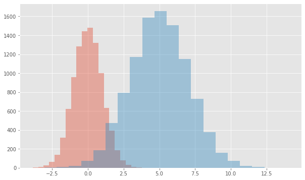

```python
plt.figure(figsize=(10,6))
plt.hist(x1,bins=20,alpha=0.4)
plt.hist(x2,bins=20,alpha=0.4)
plt.show()
```

### Random Integers

```python
np.random.randint(2,size=10)
```

```
array([0, 1, 0, 1, 1, 0, 1, 0, 0, 1])
```

```python
np.random.randint(5,20,size=100)
```

```
array([11,  7,  5, 12,  9,  5,  6,  5, 14, 14, 17, 17, 18, 13, 13, 11, 19,
       14, 17, 10, 12, 11, 15, 10, 15, 16, 14, 12, 18,  5, 12,  5,  8, 19,
       17, 18,  9,  6, 14, 15, 15,  6, 11, 13, 14, 19, 11, 14, 16, 13, 14,
       10, 15, 17,  8, 14, 11, 19, 10,  8, 11, 13, 15, 12, 11,  8,  7, 17,
       15, 10,  9,  7, 19,  6,  5, 19, 16, 10, 16,  6, 12,  6, 19,  8, 10,
       16,  8, 13,  8,  7,  8, 14, 18, 13,  9, 13, 18, 16,  6,  8])
```

```python
np.random.randint(5,20,size=(4,7))
```

```
array([[15, 19, 18, 10, 15, 19, 12],
       [11, 10, 16, 17, 18, 14,  9],
       [ 9, 13, 12, 17, 18, 17, 16],
       [ 6, 15,  9, 16, 18, 14, 15]])
```

## 2.5 Statistics

The most common statistical measures and information theory concepts are tersely explained in what ensues.

The following list of ages is used for demonstration purpose throughout this topic.

```python
ages=[15, 19,  9, 14,  7, 19, 13, 16, 14, 14,  8, 10, 17, 18,  7,  6, 19, 14,14]
ages
```

```
[15, 19, 9, 14, 7, 19, 13, 16, 14, 14, 8, 10, 17, 18, 7, 6, 19, 14, 14]
```

List Sorting Techniques

```python
# Sorting list of Integers in ascending
numbers = [1, 3, 4, 2]
numbers.sort()
print(numbers)
```

```
[1, 2, 3, 4]
```

```python
# Sorting list of Integers in descending
numbers = [1, 3, 4, 2]
numbers.sort(reverse = True)
print(numbers)
```

```
[4, 3, 2, 1]
```

```python
#First sort the ages list in ascending order
ages.sort()
```

#### Sample/Population size (N)

```python
N=len(ages)
N
```

```
19
```

#### Mean ($\mu$ or $\bar{x}$)

$\mu = \frac{\sum_{i}^N x_{i}}{N}$

```python
from statistics import mean
mean=mean(ages)
print(f"The mean of the ages list is {round(mean,2)}")
```

```
The mean of the ages list is 13.32
```

#### Median

$Median = \frac{1}{2}(x[\frac{N}{2}]+x[\frac{N}{2}+1])$ for even N  
$Median = x[int(\frac{N}{2})]$ for odd N

```python
from statistics import median
med=median(ages)
print(f"The median of the ages list is {med}")
```

```
The median of the ages list is 14
```

#### Mode ($\theta$)

$\theta = Most frequent value in the sample$  
It must be unique (only one mode; otherwise, error is generated)

```python
from statistics import mode
mode=mode(ages)
print(f"The mode of the ages list is {mode}")
```

```
The mode of the ages list is 14
```

#### Range

$range=max(ages)-min(ages)$

```python
# The difference between max and min elements of the sample
rangeval=max(ages)-min(ages)
print(f"The range of the ages list is {max(ages)}-{min(ages)}={rangeval}")
```

```
The range of the ages list is 19-6=13
```

#### Variance

It is the expectation of the squared deviation of a random variable from its mean. Informally, it measures how far a set of numbers are spread out from their average value.

```python
from statistics import variance
var=variance(ages)
print(f"The variance of the ages list is {round(var,2)}")
```

```
The variance of the ages list is 18.67
```

#### Standard Deviation

It is the square root of the average of the squared deviations from the mean.  
$\sigma = \sqrt(\frac{\sum_{i}^N (x_{i}-\bar{x})^2}{N})$

#### Quantiles

Refers to each of any set of values of a variate which divide a frequency distribution into equal groups, each containing the same fraction of the total population.

There are thre quartiles: Q1 is the median of the lower half (smaller than the median) of the population after it has been sorted in ascending order. Q2 is the same as the median of the population. Q3 is the median of the the upper half (greater than the median) of the population.

```python
import numpy as np
Qs=np.quantile(ages,[0.25,0.5,0.75])
print(f"Q1 is {round(Qs[0],2)}, Q2 is {round(Qs[1],2)}, and Q3 is {round(Qs[2],2)}")
```

```
Q1 is 9.5, Q2 is 14.0, and Q3 is 16.5
```

```python
# Proof
ages.sort()
ages
```

```
[6, 7, 7, 8, 9, 10, 13, 14, 14, 14, 14, 14, 15, 16, 17, 18, 19, 19, 19]
```

```python
l=[6, 7, 7, 8, 9, 10, 13, 14, 14,14]
median(l)
```

```
9.5
```

#### Percentiles

A percentile is a measure used in statistics indicating the value below which a given percentage of observations in a group of observations falls. $R=\frac{P}{100}*N$

```python
import numpy as np
Ps=np.percentile(ages,[1,2,25,50,75,100]) #1st, 2nd, 25th, 50th, & 100th percentiles
print(f"1stP   2ndP   25thP   50thP   100thP   ")
print(f"--------------------------------------- ")
print(f"{round(Ps[0],2)}   {round(Ps[1],2)}   {round(Ps[2],2)}   {round(Ps[3],2)}   {round(Ps[4],2)}")
```

[output not shown]

```python
np.percentile(ages,1, axis=0)
```

```
6.18
```

```python
np.percentile(ages,2, axis=0)
```

```
6.359999999999999
```

```python
np.percentile(ages,25, axis=0)
```

```
9.5
```

```python
np.percentile(ages,50, axis=0)
```

```
14.0
```

#### Maximum

```python
max(ages)
```

```
19
```

#### Minimum

```python
min(ages)
```

```
6
```

#### Covariance

ovariance provides a measure of the strength of the correlation between two or more sets of random variates. The covariance for two random variates and , each with sample size , is defined by the expectation value.

$cov(X,Y)=cov(Y,X)=E<(X-\mu_{x})(Y-\mu_{y})>=<X><Y>-\mu_{x}\mu_{y}$  
$cov(X,Y)=\frac{\sum_{i}^{N}((x_{i}-\mu_{x})(y_{i}-\mu_{y}))}{N}$

For uncorrelated variates: $cov(X,Y)=0$

However, if the variables are correlated in some way, then their covariance will be nonzero

Self-covariance is equal to the variance: $cov(X,X)=<X^2>-<X>^2=\sigma_{xx}^2$

Variance in terms of covariance  
$Var(X+Y)=Var(X)+Var(Y)+2*cov(X,Y)$

$cov(X+Z,Y)=cov(X,Z)+cov(Z,Y)$

```python
np.cov(ages,ages)
```

```
array([[18.67251462, 18.67251462],
       [18.67251462, 18.67251462]])
```

```python
x=np.array(ages)
y= np.arange(19)
```

```python
np.cov(x,x)
```

```
array([[18.67251462, 18.67251462],
       [18.67251462, 18.67251462]])
```

```python
np.cov(y,y)
```

```
array([[31.66666667, 31.66666667],
       [31.66666667, 31.66666667]])
```

```python
np.cov(x,y)
```

```
array([[18.67251462, 23.72222222],
       [23.72222222, 31.66666667]])
```

```python
#The slef-covariance of X
np.cov(x,y)[0][0]
```

```
18.67251461988304
```

```python
#The slef-covariance of y
np.cov(x,y)[1][1]
```

```
31.666666666666664
```

```python
#The covariance of X and Y
np.cov(x,y)[0][1]
```

```
23.722222222222218
```

```python
np.cov(x,y)[1][0]
```

```
23.722222222222218
```

#### Correlation

A statistical measure that indicates the extent to which two or more variables fluctuate together. A positive correlation indicates the extent to which those variables increase or decrease in parallel; a negative correlation indicates the extent to which one variable increases as the other decreases.

$cor(X,Y)=\frac{cov(X,Y)}{\sigma_{X}\sigma_{y}}=\frac{\sigma_{xy}}{\sqrt(\sigma_{xx}\sigma_{yy})}$

```python
np.corrcoef(x, y)
```

```
array([[1.        , 0.97555732],
       [0.97555732, 1.        ]])
```

```python
# The correlation of x and y
np.corrcoef(x, y)[0][1]
```

```
0.9755573168733159
```

```python
np.corrcoef(x, y)[1][0]
```

```
0.9755573168733157
```

```python
import numpy as np

np.random.seed(1)

# 1000 random integers between 0 and 50
x = np.random.randint(0, 50, 1000)
# Positive Correlation with some noise
y = x + np.random.normal(0, 10, 1000)
np.corrcoef(x, y)
```

```
array([[1.        , 0.81543901],
       [0.81543901, 1.        ]])
```

Positive correlation

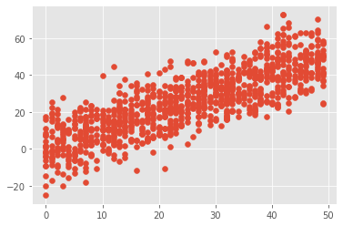

```python
import matplotlib
import matplotlib.pyplot as plt
%matplotlib inline
matplotlib.style.use('ggplot')

plt.scatter(x, y)
plt.show()
```

Negative Correlation

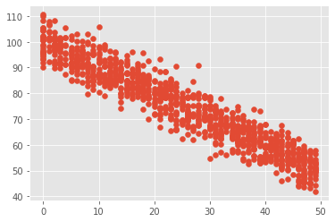

```python
# 1000 random integers between 0 and 50
x = np.random.randint(0, 50, 1000)

# Negative Correlation with some noise
y = 100 - x + np.random.normal(0, 5, 1000)

np.corrcoef(x, y)
plt.scatter(x, y)
plt.show()
```

Weak COrrelation

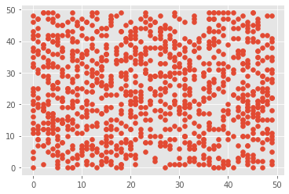

```python
x = np.random.randint(0, 50, 1000)
y = np.random.randint(0, 50, 1000)

np.corrcoef(x, y)
plt.scatter(x, y)
plt.show()
```

Correlation Matrix

```python
import pandas as pd

df = pd.DataFrame({'a': np.random.randint(0, 50, 1000)})
df['b'] = df['a'] + np.random.normal(0, 10, 1000) # positively correlated with 'a'
df['c'] = 100 - df['a'] + np.random.normal(0, 5, 1000) # negatively correlated with 'a'
df['d'] = np.random.randint(0, 50, 1000) # not correlated with 'a'

df.corr()
```

|  | a | b | c | d |
| --- | --- | --- | --- | --- |
| a | 1.000000 | 0.825361 | -0.948845 | 0.009802 |
| b | 0.825361 | 1.000000 | -0.789391 | 0.011852 |
| c | -0.948845 | -0.789391 | 1.000000 | -0.003228 |
| d | 0.009802 | 0.011852 | -0.003228 | 1.000000 |

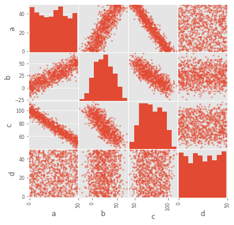

```python
pd.plotting.scatter_matrix(df, figsize=(6, 6))
plt.show()
```

Direct plot of correlations

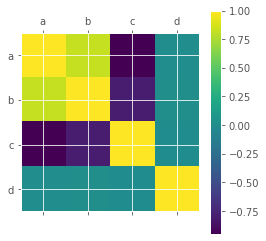

```python
plt.matshow(df.corr())
plt.xticks(range(len(df.columns)), df.columns)
plt.yticks(range(len(df.columns)), df.columns)
plt.colorbar()
plt.show()
```

#### Information Measure (Units=Bits, nats, or Hartleys)

$I(x)=-log(p(x))$

```python
x=[2,10,5,6,7,8]
prob=[1/6,1/6,1/6,1/6,1/6,1/6]
import math
I=[round(-math.log2(p),2) for p in prob]
I
```

```
[2.58, 2.58, 2.58, 2.58, 2.58, 2.58]
```

#### Entropy

Avergae information measure

Measure of uncertainity

$H(x)=-\sum_{i}^{N}p(x)log(p(x))$

```python
x=[2,10,5,6,7,8]
prob=[1/6,1/6,1/6,1/6,1/6,1/6]
import math
h=[round(-p*math.log2(p),2) for p in prob]
H=sum(h)
H
```

```
2.58
```

#### Kullback–Leibler divergence

In mathematical statistics, the Kullback–Leibler divergence (also called relative entropy) is a measure of how one probability distribution is different from a second, reference probability distribution. Applications include characterizing the relative (Shannon) entropy in information systems, randomness in continuous time-series, and information gain when comparing statistical models of inference.

For discrete probability distributions P and Q defined on the same probability space, the Kullback–Leibler divergence between P and Q is defined to be

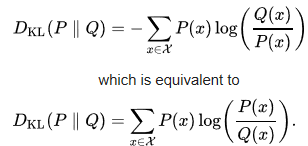

```python
from IPython.display import Image
from IPython.core.display import HTML
Image('ds_30.png')
```

```python
x=[0,1,2]
probx=[0.36,0.48,0.16]
proby=[0.333,0.333,0.333]
```

```python
#Log2  --> bits
import math
h1=[]
for i in range(len(x)):
    t=probx[i]*math.log2(probx[i]/proby[i])
    h1.append(t)
H1=sum(h1)
print(f"P||Q is {round(H1,2)}")

h2=[]
for i in range(len(x)):
    t=proby[i]*math.log2(proby[i]/probx[i])
    h2.append(t)
H2=sum(h2)
print(f"Q||P is {round(H2,2)}")
```

```
P||Q is 0.12
Q||P is 0.14
```

```python
#Natural Logarithm  --> nats
import math
import numpy as np
h3=[]
for i in range(len(x)):
    t=probx[i]*np.log(probx[i]/proby[i])
    h3.append(t)
H3=sum(h3)
print(f"P||Q is {round(H3,6)}")

h4=[]
for i in range(len(x)):
    t=proby[i]*np.log(proby[i]/probx[i])
    h4.append(t)
H4=sum(h4)
print(f"Q||P is {round(H4,6)}")
```

[output not shown]

### NB: Section 4 through section 15 are on separate files